# General Social Survey

Victor Cardenas

April 20, 2019

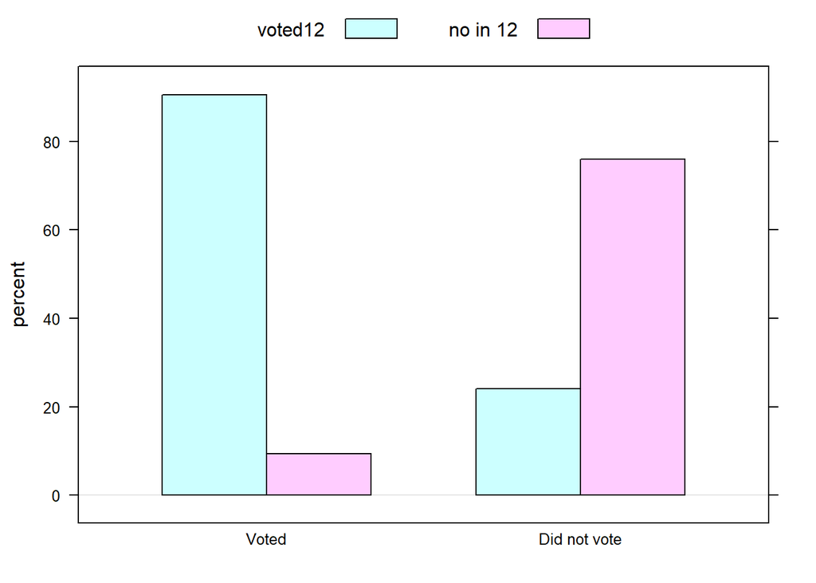

```r
barchartGC(~VOTE16+VOTE12, data=mydata4, type = "percent")
```

```r
chisqtestGC(~VOTE16+VOTE12, data=mydata4)
```

```
## Pearson's Chi-squared test with Yates' continuity correction
##
## Observed Counts:
##               VOTE12
## VOTE16         voted12 no in 12
##   Voted            116       12
##   Did not vote      12       38
##
## Counts Expected by Null:
##               VOTE12
## VOTE16         voted12 no in 12
##   Voted          92.04    35.96
##   Did not vote   35.96    14.04
##
## Contributions to the chi-square statistic:
##               VOTE12
## VOTE16         voted12 no in 12
##   Voted           6.23    15.96
##   Did not vote   15.96    40.86
##
##
## Chi-Square Statistic = 75.7483
## Degrees of Freedom of the table = 1
## P-Value = 0
```

```r
votetab=xtabs(~VOTE16+VOTE12, data=mydata4)
fisher.test(votetab)
```

```
##
##  Fisher's Exact Test for Count Data
##
## data:  votetab
## p-value < 2.2e-16
## alternative hypothesis: true odds ratio is not equal to 1
## 95 percent confidence interval:
##  11.74522 81.42075
## sample estimates:
## odds ratio
##   29.60721
```

# 1 Introduction Question 1

This data is from the 2018 General Social Survey. The first blocks of R-code has selected down a subset of the data to just 15 variables. It has further removed unwanted factor levels in much of the data. Examine that code to see what it is doing. First explain what you make out of comparing how people voted in 2012 with 2016.

How are the “voted in 2016” and “Voted in 2012” related? $H_O:$ voting in 2016 and 2012 are unrelated. Alternative : If voting in 2016 is related to voting in 2012

## 1.1 Methods

Use categorical variables, and a chi-squared test to test the hypothesis that voting in 2016 is or is not independent of voting in 2012.

## 1.2 Results

We use a barchart to show the voting trends between 2012 and 2016.

### 1.2.1 Descriptive Results

#### 1.2.1.1 Graphical Descriptive Results

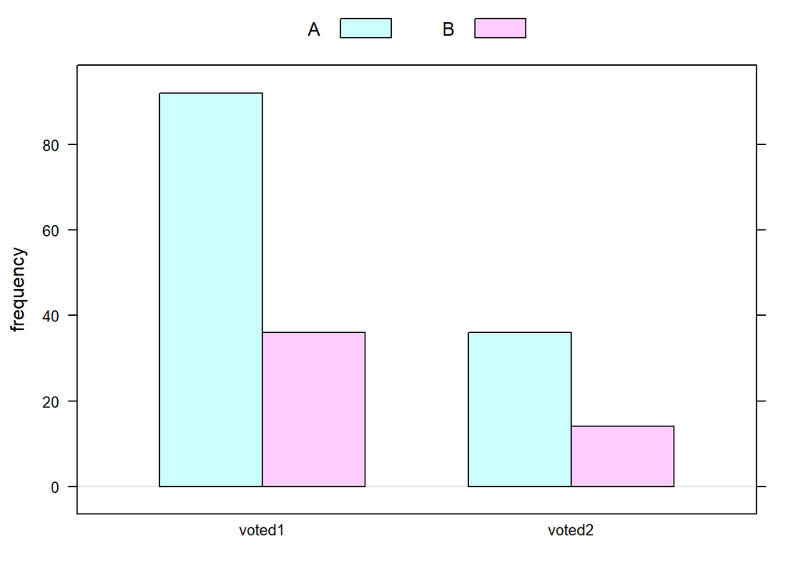

```r
voted1=c(92.04 , 35.96)
voted2=c(35.96 , 14.04)
tabl = rbind(voted1,voted2)
barchartGC(tabl)
```

### 1.2.2 Inferential Results

$H_0$ : There is a relationship between those who voted in 2012 and 2016. $H_A$ : There is no relationship between those who voted in 2012 and 2016.

```r
chisqtestGC(~VOTE16+VOTE12, data=mydata4)
```

```
## Pearson's Chi-squared test with Yates' continuity correction
##
## Observed Counts:
##               VOTE12
## VOTE16         voted12 no in 12
##   Voted            116       12
##   Did not vote      12       38
##
## Counts Expected by Null:
##               VOTE12
## VOTE16         voted12 no in 12
##   Voted          92.04    35.96
##   Did not vote   35.96    14.04
##
## Contributions to the chi-square statistic:
##               VOTE12
## VOTE16         voted12 no in 12
##   Voted           6.23    15.96
##   Did not vote   15.96    40.86
##
##
## Chi-Square Statistic = 75.7483
## Degrees of Freedom of the table = 1
## P-Value = 0
```

```r
votetab=xtabs(~VOTE16+VOTE12, data=mydata4)
fisher.test(votetab)
```

```
##
##  Fisher's Exact Test for Count Data
##
## data:  votetab
## p-value < 2.2e-16
## alternative hypothesis: true odds ratio is not equal to 1
## 95 percent confidence interval:
##  11.74522 81.42075
## sample estimates:
## odds ratio
##   29.60721
```

if you voted in 2012 and 2016 are related? we used a p-value and 2012 is related to 2016.

The hypothesis was that voting in 2012 is related to voting in 2016. we used a chi-square test of independence. p value is 0, meaning the null hypothesis is related. we reject te null hypothesis. there is evidence that voting in 2012 is related to voting in 2016 and if you did not vote 2012 you probably did not vote in 2016.

# 2 Introduction Question 2

Now answer Is belief in the bigbang theory (BIGBANG) independent of belief in the afterlife (POSTLIFE)

How are the “big bang theory” and “belief in after life” related?

$H_0:$ if people believ in the big bang also believe in the after life.

alternative hypothesis: there is no relation between people who believe in the big bang theory and people who believe in the after life.

## 2.1 Methods

We will use categorical variables, and a chi-squared test to test the belief in the big bang theory is not independent of the belief in an after life.

## 2.2 Results

### 2.2.1 Descriptive Results

#### 2.2.1.1 Graphical Descriptive Results

[figure not shown]

```r
barchartGC(~BIGBANG+POSTLIFE, data=mydata3, type = "percent",xlab='Belief in the Afterlife',main = 'BELEIVE IN BIGBANG')
```

### 2.2.2 Inferential Results

```r
chisqtestGC(~BIGBANG+POSTLIFE, data=mydata4)
```

```
## Pearson's Chi-squared test with Yates' continuity correction
##
## Observed Counts:
##        POSTLIFE
## BIGBANG YES NO
##   True   67 15
##   False  88  8
##
## Counts Expected by Null:
##        POSTLIFE
## BIGBANG  YES   NO
##   True  71.4 10.6
##   False 83.6 12.4
##
## Contributions to the chi-square statistic:
##        POSTLIFE
## BIGBANG  YES   NO
##   True  0.27 1.83
##   False 0.23 1.56
##
##
## Chi-Square Statistic = 3.0637
## Degrees of Freedom of the table = 1
## P-Value = 0.0801
```

```r
Bangtab=xtabs(~BIGBANG+POSTLIFE, data=mydata4)
fisher.test(Bangtab)
```

```
##
##  Fisher's Exact Test for Count Data
##
## data:  Bangtab
## p-value = 0.07143
## alternative hypothesis: true odds ratio is not equal to 1
## 95 percent confidence interval:
##  0.1410591 1.0968350
## sample estimates:
## odds ratio
##  0.4081275
```

# 3 Introduction Question 3

This time compare the opinion on death penalty (CAPPUN) with opinion on courts (COURTS). $H_0:$ if people believe in the courts, they also believe in the death penalty

alternative hypothesis: there is no relation to people’s view on the courts and people who believe in the death penalty

## 3.1 Methods

we will use categorical variables, and a chi-squared test to test the belief in the death penalty and that it is not independent of the belief in the court system.

## 3.2 Results

### 3.2.1 Descriptive Results

#### 3.2.1.1 Graphical Descriptive Results

[figure not shown]

```r
barchartGC(~CAPPUN+COURTS, data=mydata4, type = "percent",xlab='Opinion on Courts',main = 'OPINION ON DEATH PENALTY')
```

### 3.2.2 Inferential Results

```r
chisqtestGC(~CAPPUN+COURTS, data=mydata4)
```

```
## Pearson's Chi-squared test
##
## Observed Counts:
##         COURTS
## CAPPUN   TOO HARSH NOT HARSH ENOUGH ABOUT RIGHT
##   FAVOR         13               93          10
##   OPPOSE        31               20          11
##
## Counts Expected by Null:
##         COURTS
## CAPPUN   TOO HARSH NOT HARSH ENOUGH ABOUT RIGHT
##   FAVOR      28.67            73.64       13.69
##   OPPOSE     15.33            39.36        7.31
##
## Contributions to the chi-square statistic:
##         COURTS
## CAPPUN   TOO HARSH NOT HARSH ENOUGH ABOUT RIGHT
##   FAVOR       8.57             5.09        0.99
##   OPPOSE     16.03             9.52        1.86
##
##
## Chi-Square Statistic = 42.0594
## Degrees of Freedom of the table = 2
## P-Value = 0
```

```r
CAPtab=xtabs(~CAPPUN+COURTS, data=mydata4)
fisher.test(CAPtab)
```

```
##
##  Fisher's Exact Test for Count Data
##
## data:  CAPtab
## p-value = 4.35e-10
## alternative hypothesis: two.sided
```

# 4 Discussion and Conclusion

The hypothesis was that belief in the death penalty is related to the belief in the court syste. We used a chi-square test of independence. the p value is 0, which means the null hypothesis is related. we reject the null hypothesis since we have evidence that the belief in the death penalty is related to the beliefs of others in the court system. if we did not likely believe in the death penalty you likely did not believe in the court system.